# Assignment

# Introduction

This dataset gives information about the largest online store in Brazil - ‘Olist’. Small businesses can use the platform to sell their products on the side and ship them by using the Olist logistic partners.  
The dataset contains (pseudo-) anonymised data of orders from 2016 to 2018.

# Data exploratory

Importing the libraries

Joining the tables together

We want to focus the data analysis on one business year, therefore the data is filtered to only contain orders which have been approved in 2017. The data now contains orders from 2017-01-05 to 2017-12-31.

```
##                           order_id                      customer_id
## 1 e481f51cbdc54678b7cc49136f2d6af7 9ef432eb6251297304e76186b10a928d
## 2 949d5b44dbf5de918fe9c16f97b45f8a f88197465ea7920adcdbec7375364d82
## 3 a4591c265e18cb1dcee52889e2d8acc3 503740e9ca751ccdda7ba28e9ab8f608
## 4 136cce7faa42fdb2cefd53fdc79a6098 ed0271e0b7da060a393796590e7b737a
## 5 6514b8ad8028c9f2cc2374ded245783f 9bdf08b4b3b52b5526ff42d37d47f222
##   order_status order_purchase_timestamp order_approved_at
## 1    delivered      2017-10-02 10:56:33        2017-10-02
## 2    delivered      2017-11-18 19:28:06        2017-11-18
## 3    delivered      2017-07-09 21:57:05        2017-07-09
## 4     invoiced      2017-04-11 12:22:08        2017-04-13
## 5    delivered      2017-05-16 13:10:30        2017-05-16
##   order_delivered_carrier_date order_delivered_customer_date
## 1          2017-10-04 19:55:00           2017-10-10 21:25:13
## 2          2017-11-22 13:39:59           2017-12-02 00:28:42
```

[output cut: 27 more lines]

## Comparing the different states

The next plots show the amount of orders per state from 2017 and the total revenue made by each state in 2017

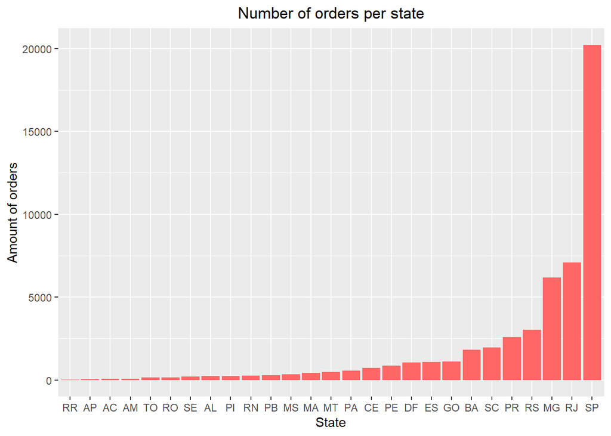

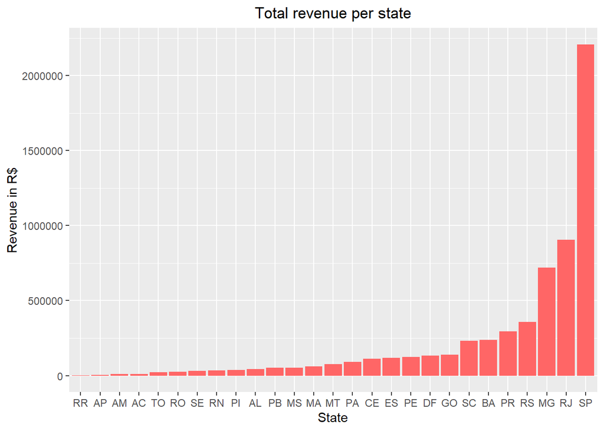

The next plot compares the amount of orders with the revenue using normalized data.

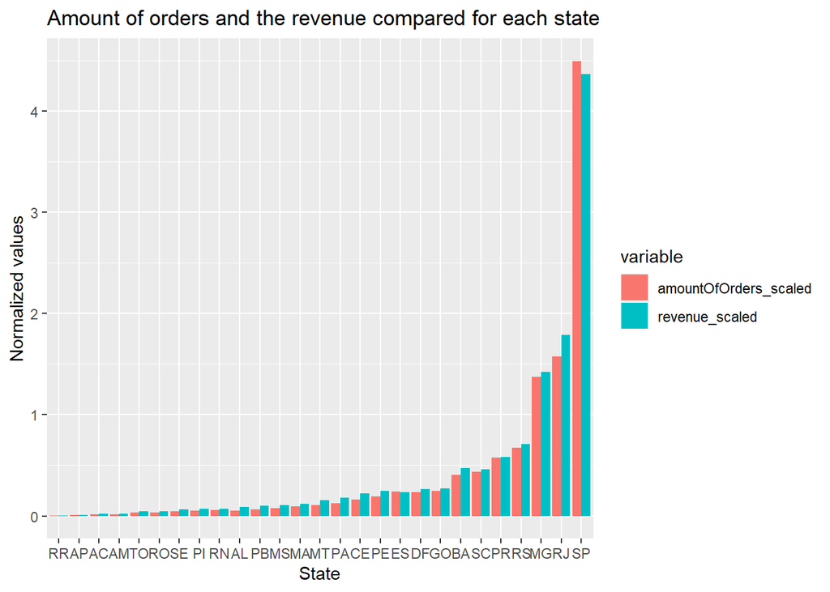

You can see that there is a correlation between both variables, although the ratio between the amount and the revenue varies a bit. So in the next step we want to take a look at the average price of one order grouped by the different states.

So we create a new table which contains the average price per order for each state. Therefore we have to calculate the total order price first and after that we can group by the customer state and calculate the average.

Here is the bar chart showing these values.

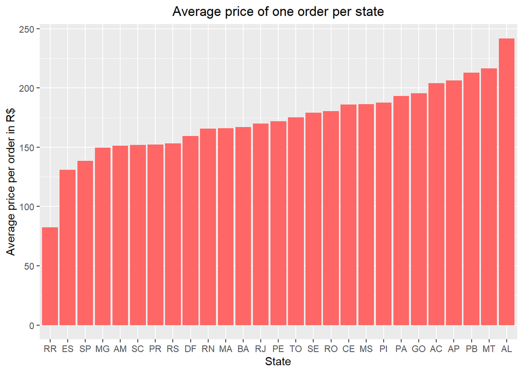

You can clearly see that there is a huge variance in the price per one order for the different states. Ranging from 82.52R$ in Roraima to 241.88R$ in Alagoas.

In the next plot we want to take a look at the money customers spend in one year. Therefore we take a look at the distribution of that value comparing the four states that made the most revenue in 2017 (SP, RJ, MG, RS).  
We filtered out customers spending more then 1000R$ because there seem to be a few major customers which would make the plot unreadable.

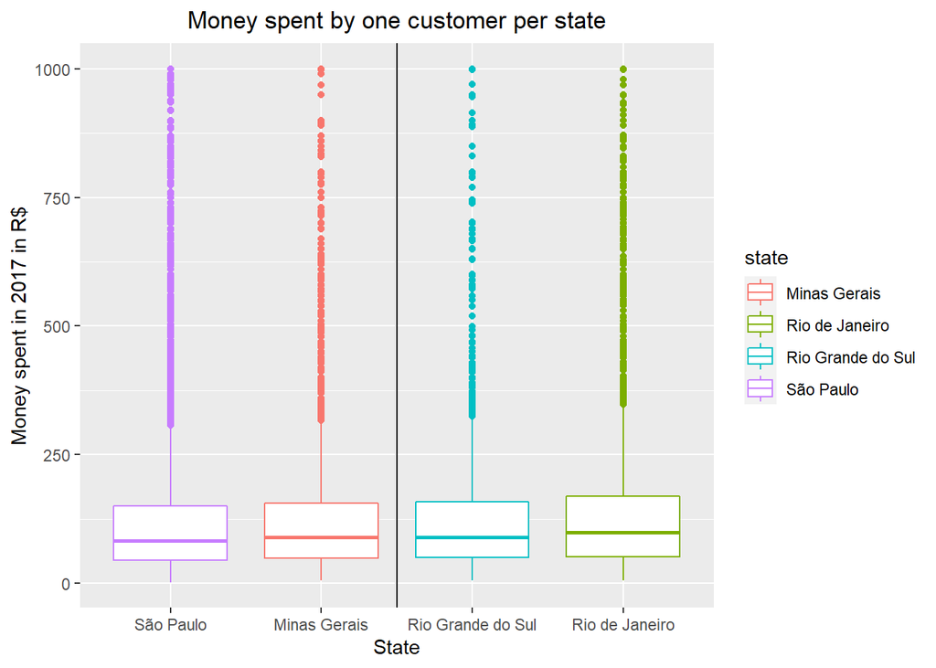

Although São Paulo makes the most revenue by far, the distribution seems to be almost equal, The median is almost the same and the 50% interval is almost the same. So the it looks like there is another variables, influencing the revenue made by a state. So let us take a look at the revenue made by a state compared with it’s population.

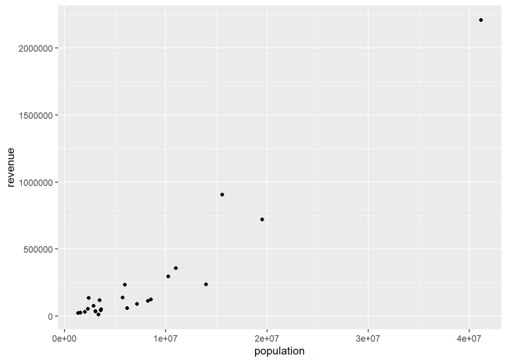

This looks like there is a correlation between those variables. This will be analyzed in detail in the Regression part of this Assignment.

# Sellers

Revenue from top 10 sellers for 2017

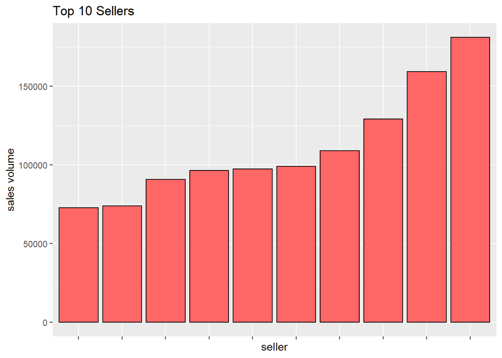

From this data you can see, that the biggest generated revenue per seller, ranges from 72833.60R$ to 181113.92R$.

Best reviewed Sellers. Count of reviews having at least 4 Stars

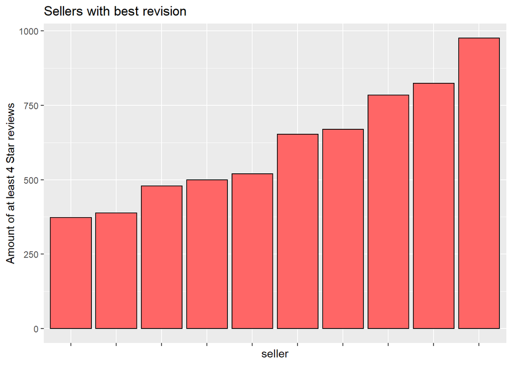

This data represent the best sellers on the platfrom regarding the amount of good revisions(the amount of at least 4 star revision).

Total sales per category

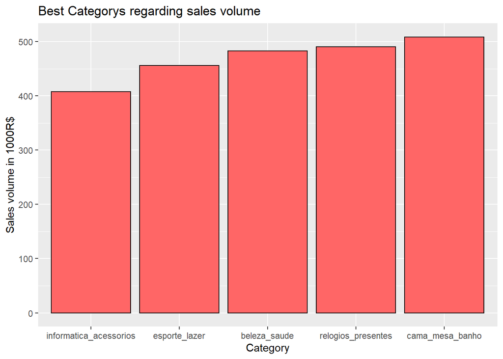

# Regression (Niklas)

The first regression model I thought of, was to predict the revenue made by a state depending on the population of that state. There are 3 states in Brazil with a population of less than 1000, so I decided to exclude them because they are not representative enough. Below are the results of this regression model.

```
##
## Call:
## lm(formula = revenue ~ population, data = revnue_state_info)
##
## Residuals:
##     Min      1Q  Median      3Q     Max
## -344741  -97940   20394   84877  238002
##
## Coefficients:
##               Estimate Std. Error t value Pr(>|t|)
## (Intercept) -1.512e+05  3.833e+04  -3.945 0.000689 ***
## population   5.250e-02  3.354e-03  15.650 2.09e-13 ***
## ---
## Signif. codes:  0 '***' 0.001 '**' 0.01 '*' 0.05 '.' 0.1 ' ' 1
##
## Residual standard error: 138100 on 22 degrees of freedom
## Multiple R-squared:  0.9176, Adjusted R-squared:  0.9138
## F-statistic: 244.9 on 1 and 22 DF,  p-value: 2.086e-13
```

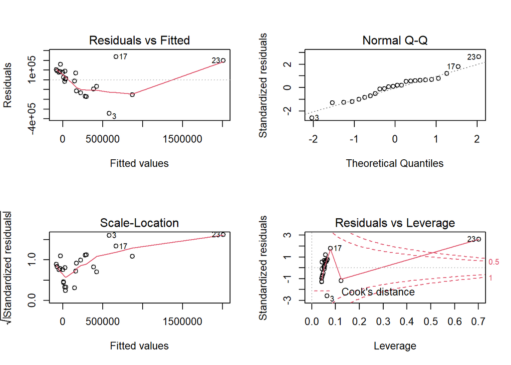

Looking at the summary of the regression, it seems to fit quite well. The p-value is pretty low and the R-squared value is high. That means that the data values fit on the regression model quite well.  
The standard error for the revenue is a bit high with about 38330R$ but we are talking about large revenue numbers here so that is still okay.  
Regarding the regression plots, there is one outlier, which you can see in the Normal Q-Q plot and especially the Scale-Location plot. The number 23 which represents the state São Paulo. This value probably stands out a bit because São Paulo is like the center of commerce in Brazil. Therefore I think it is acceptable that this data point stands out a bit.  
Overall I would say the regression model fits the 4 assumptions made for a linear regression.  
So how to interpret the regression outcome now?  
So what the linear regression model tells us now, is that the the revenue would start at about -151200R$ for a population of 0, which does not really make sense in this context but in this model I don’t want to predict the revenue for states with low population, that is not really significant, instead we are dealing with population numbers of over 1 million. The other estimate value tells us, for each increase in the population by 1, the revenue generated by that state will increase by 0.0525R$.  
To conclude I would say the regression model can predict the the revenue a state will generate depending on the population. Not perfect but it can give an approximation.  
So I thought which variable could also affect the revenue made by a state. I came up with the idea to include the GNP (gross national product) of the state into the regression model. So first of all I checked if these two variables are collinear. Therefore I use the “cor()” function to see if the variables correlate.

```
## [1] 0.1220328
```

A value near 0 is good here, so we can assume that there is no collinearity between these variables. So below we see the results of the regression with both variables, the population and GNP as predictors for the revenue.

```
##
## Call:
## lm(formula = revenue ~ gnp + population, data = revnue_state_info2)
##
## Residuals:
##     Min      1Q  Median      3Q     Max
## -224983  -64113   23286   72329  148990
##
## Coefficients:
##               Estimate Std. Error t value Pr(>|t|)
## (Intercept) -2.638e+05  3.741e+04  -7.051 5.85e-07 ***
## gnp          1.864e+01  4.123e+00   4.522 0.000187 ***
## population   5.114e-02  2.462e-03  20.769 1.76e-15 ***
## ---
## Signif. codes:  0 '***' 0.001 '**' 0.01 '*' 0.05 '.' 0.1 ' ' 1
##
## Residual standard error: 100600 on 21 degrees of freedom
## Multiple R-squared:  0.9582, Adjusted R-squared:  0.9543
## F-statistic: 240.9 on 2 and 21 DF,  p-value: 3.295e-15
```

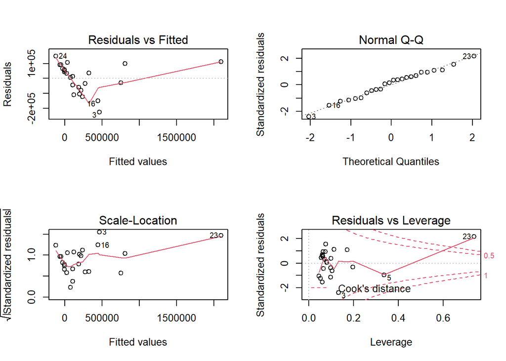

The summary show that it looks like the gnp can explain the revenue made by that state as well. The estimate for the population almost stays the same (so not a strong collinearity) and has quite a high impact on the revenue. The p-value is really low as well. So let’s make a partial F-test in order to check if this full model can be preferred over the partial model.

```
## Analysis of Variance Table
##
## Model 1: revenue ~ population
## Model 2: revenue ~ gnp + population
##   Res.Df        RSS Df  Sum of Sq     F    Pr(>F)
## 1     22 4.1939e+11
## 2     21 2.1248e+11  1 2.0691e+11 20.45 0.0001865 ***
## ---
## Signif. codes:  0 '***' 0.001 '**' 0.01 '*' 0.05 '.' 0.1 ' ' 1
```

The low P-value right here shows that we can accept the alternative hypothesis, that the full model explains the relationship better than the partial one.  
To conclude, São Paulo is still a bit of an outlier, but that can be explained by the fact that it is much more extreme in comparison to the other states.  
I think this linear model fits pretty good in terms of predicting the revenue given the two variables population and GNP.

# Regression(Felix)

## Monthly revenue regression

This regression model, predicts the revenue for the months of a year. Below there are the results for of the regression.

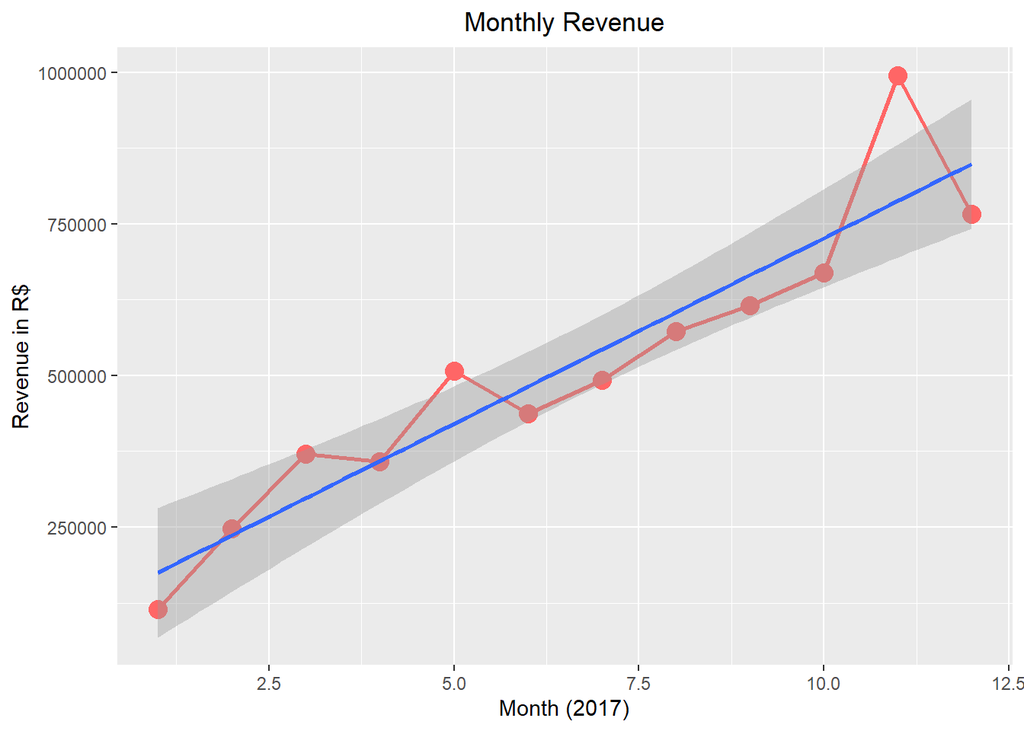

```
##
## Call:
## lm(formula = revenue_by_month ~ month, data = revenue_by_month)
##
## Residuals:
##    Min     1Q Median     3Q    Max
## -83515 -51940 -37675  26399 207054
##
## Coefficients:
##             Estimate Std. Error t value Pr(>|t|)
## (Intercept)   114016      54232   2.102   0.0618 .
## month          61253       7369   8.313  8.4e-06 ***
## ---
## Signif. codes:  0 '***' 0.001 '**' 0.01 '*' 0.05 '.' 0.1 ' ' 1
##
## Residual standard error: 88120 on 10 degrees of freedom
## Multiple R-squared:  0.8736, Adjusted R-squared:  0.8609
## F-statistic:  69.1 on 1 and 10 DF,  p-value: 8.404e-06
```

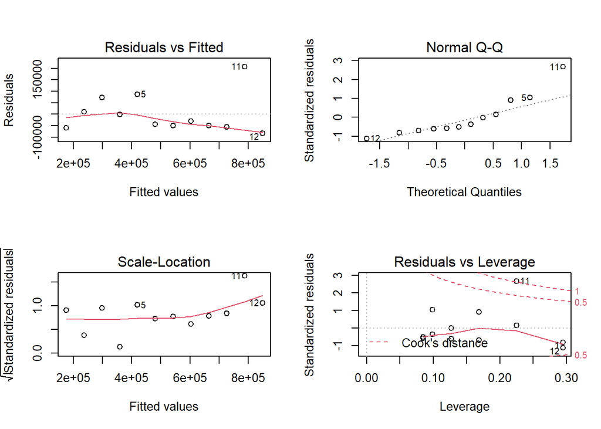

```
## [1] "Below is the regressionmodel without the 11th month"
```

```
##
## Call:
## lm(formula = revenue_by_month ~ month, data = revenue_by_month[-c(11),
##     ])
##
## Residuals:
##    Min     1Q Median     3Q    Max
## -84383 -19285  -4964   1817  96541
##
## Coefficients:
##             Estimate Std. Error t value Pr(>|t|)
## (Intercept)   146398      31415    4.66  0.00118 **
## month          52846       4530   11.67 9.79e-07 ***
## ---
## Signif. codes:  0 '***' 0.001 '**' 0.01 '*' 0.05 '.' 0.1 ' ' 1
##
## Residual standard error: 49810 on 9 degrees of freedom
## Multiple R-squared:  0.938,  Adjusted R-squared:  0.9311
## F-statistic: 136.1 on 1 and 9 DF,  p-value: 9.792e-07
```

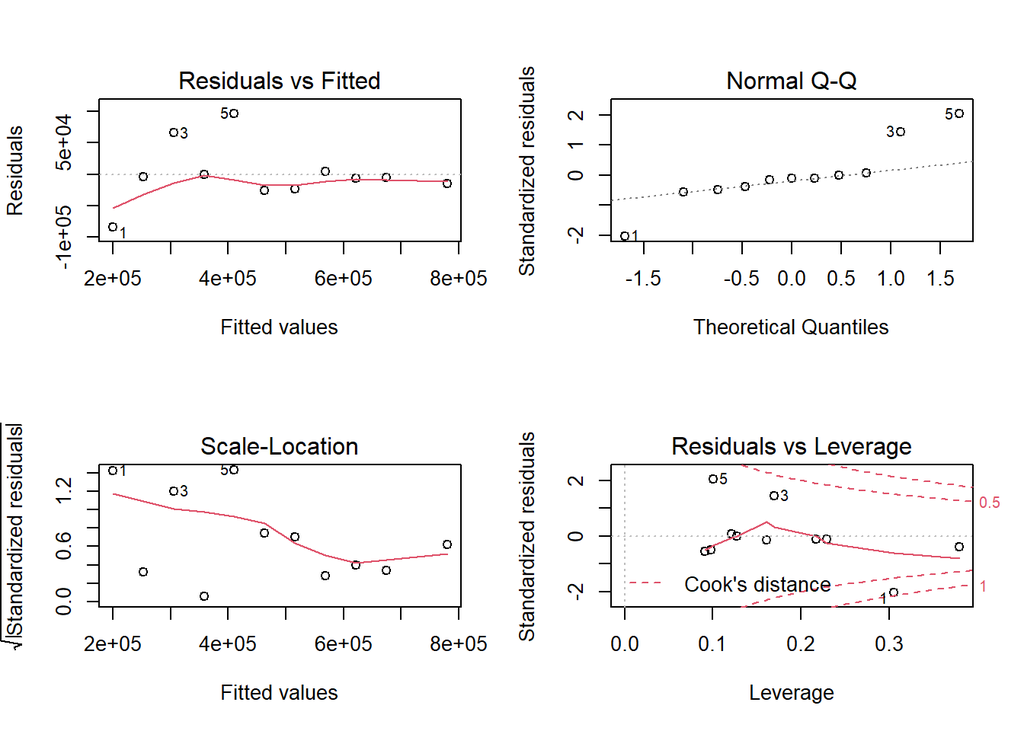

You can see that the 11th month is out of line, which ends with a R-squared value not that high. This can be traced back to events like black friday, which is a huge thing in brazil. Because of this, a regression model without the 11th month was also made. Here you can see that the prediction is better, that can be seen by the result values, with an high R-squared of 0.9311 and low a p-value of 9.792e-07. A standard error of 31415 is also ok if you keep in mind that there are millions of revenue.  
Regarding QQ-plot of the four plots of the regression you can see that in the both cases(with all months and without the 11th month) there are some deviations, what is normal because the revenue in some months like november is significant higher due to things like black friday. This can also be seen by the resudials vs leverage where the 11 month is in the right top. So overall it could be said that the regression is fitting well.  
In conclusion, the results of the regression model show that it can predict the monthly revenue quit well, except the 11th month. But if you do it without the 11th month it can be seen that the prediction for each month is way better and got good result values regarding the accuracy.